# Final Project

# Plot 2

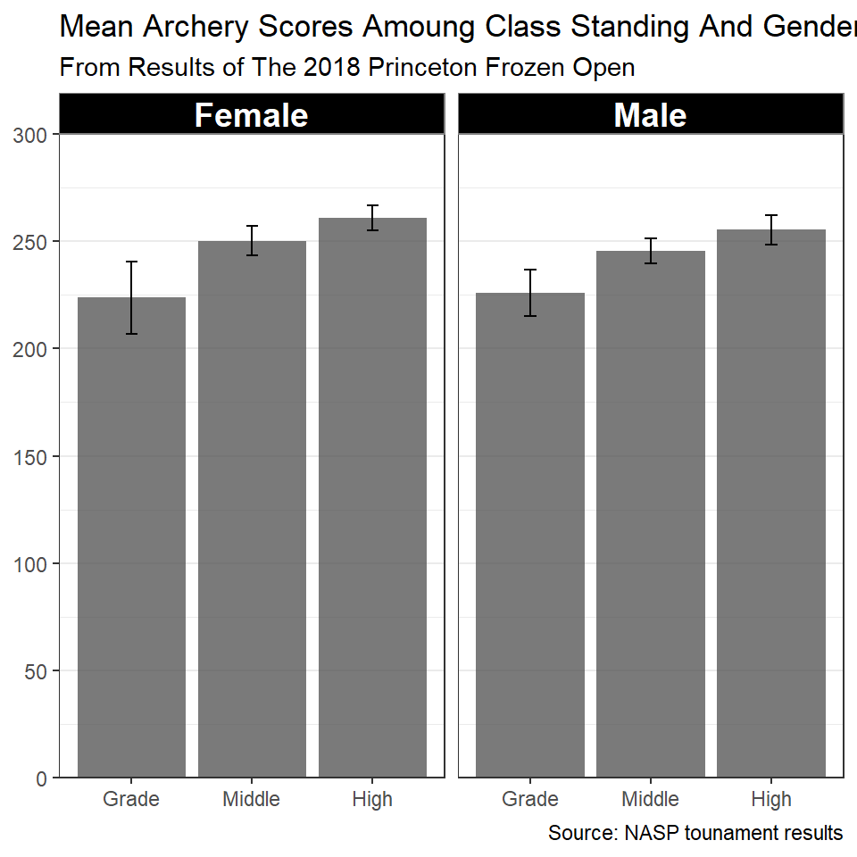

```r
ggplot(data=arch,mapping=aes(x=level,y=score))+
  stat_summary(fun=mean,geom="bar",
               fill="gray30",alpha=0.75)+
  stat_summary(fun.data=mean_cl_normal,geom="errorbar",
               width=0.1) +
  facet_wrap(vars(gender))+
  scale_x_discrete(name="Class Standing") +
  scale_y_continuous(name="Mean Score",breaks=seq(0,300,50),
                     limits=c(0,300),expand=expansion(mult=c(0,0.0))) +
  theme_bw() +
  theme(panel.grid.major.x=element_blank(),
        strip.background=element_rect(fill="black",color="gray50"),
        strip.text=element_text(color="white",size=14,margin=margin(t=2,b=2,r=2,l=2),
                                face="bold"),
        axis.title.x=element_blank(),
        axis.title.y=element_blank())+
  labs(title="Mean Archery Scores Amoung Class Standing And Gender",
       subtitle="From Results of The 2018 Princeton Frozen Open ",
       caption="Source: NASP tounament results")
```

The data are the same as in the first plot. For this plot I wanted to see if there was a difference between males and females. I decided to do a faceted bar plot because I thougt this would be the best way to show means split by 2 variables. again I thought color was unessisary so I kept it on a grey scale. I added error bars because I thought it was incompleat to show means without uncertanty. After adding the title the axis felt redundent so I removed them. The facest lables were ugly so I thined them out a bit, made the background black, and made the text bold.